## Predictive Modeling on Human Activity Recognition

Jürgen Riedel, May 24th 2015

### Introduction

A recent development is wearable technology, which has the goal to integrate technology into the everyday life. Friction less wearable devices, such as watches, armband, belts, etc. can monitor our daily movement on multi-dimensional ways by employing accelerometers, gyrometers and other electronic sensors. These devices produce massive amount of data which posses a challenge to be processed to understand the underlying information about the users of these devices.

The goal of this study is to use the data of Velloso, E. et al. project. In Velloso’s program, a group of tester was required to perform 5 type of movements (here simplified as capital letter A ~ E), with sensor device positioned on 4 part of the body and a set of time sequence data is produced. The goal is to predict the manner in which they did the exercise, indicated by the “classe” variable in the data set.

The study is structured as follows:

1. Load the training and testing data
2. Conduct exploratory data analysis
3. Preprocess the data and eliminate not useful variables
4. Perform predictor selection
5. Evaluate three models and evaluate the prediction accuracy and out of sample error of the three models
6. Select the best model and apply it to the test set to get the prediction

### Data Processing

##### Load dataset

We load the training set and test set from the website [Data Source](https://class.coursera.org/predmachlearn-014/human_grading/view/courses/973549/assessments/4/submissions). The original data can be retrieved from this source: [Original Data Source](https://class.coursera.org/predmachlearn-014/human_grading/view/courses/973549/assessments/4/submissions)

```r
require("RCurl")
training <- read.csv(text = getURL("https://d396qusza40orc.cloudfront.net/predmachlearn/pml-training.csv"),na.strings = '')
testing <- read.csv(text = getURL("https://d396qusza40orc.cloudfront.net/predmachlearn/pml-testing.csv"),na.strings = '')
```

##### Drop unwanted columns

First we look at the variables in the training data set. The first 7 variables

```r
library(xtable)
result <- data.frame(colnames(testing[,1:7]))
colnames(result) <- c("Non essential variables")
print(xtable(result, caption = "Non essential variables for prediction"), type="html", comment=F)
```

Non essential variables for prediction

|  | Non essential variables |
| --- | --- |
| 1 | X |
| 2 | user_name |
| 3 | raw_timestamp_part_1 |
| 4 | raw_timestamp_part_2 |
| 5 | cvtd_timestamp |
| 6 | new_window |
| 7 | num_window |

are not measurements and we therefore exclude them from our training and test data sets.

```r
training <- subset( training, select = -c(1:7))
testing <- subset( testing, select = -c(1:7))
```

The remaining variables in the data set contain summaries of other variables and are not numeric, i.e. kurtoses, skewnesses, maximums and minimums, amplitudes, variances, averages, and standard deviations. Since we are only interested variables which are directly human motion measurements, we are removing those as well from our data sets.

```r
## Get column names of data set
colnames <- colnames(training)

exclude <- grepl('kurtosis|skewness|max|min|amplitude|var|avg|stddev', colnames)

training <- training[,!(exclude)]
testing <- testing[,!(exclude)]
```

### Preprocessing

##### Create training and testing sets

```r
library(caret);
set.seed(10302010)

trainIndex <- createDataPartition(y=training$classe, p=0.75, list=FALSE)
trainingSet<- training[trainIndex,]
testingSet<- training[-trainIndex,]
```

Check if data sets are NA free.

```r
## Check if any NA values left in data set
NAtrain <- any(sapply(trainingSet, function(x) any(is.na(x))))
NAtest <- any(sapply(testingSet, function(x) any(is.na(x))))

isNA <- data.frame(rbind(c("Training Set",NAtrain),c("Test Set",NAtest)))
colnames(isNA) <- c("Data Set", "Has NAs")
print(xtable(isNA, caption = "NA check for data sets"), type="html", comment=F)
```

NA check for data sets

|  | Data Set | Has NAs |
| --- | --- | --- |
| 1 | Training Set | FALSE |
| 2 | Test Set | FALSE |

##### Random forest predictor selection

The randomForest() method implements Breiman’s random forest algorithm (based on Breiman and Cutler’s original Fortran code) for classification and regression. Random forests are very good for classification and regression. It uses multiple models for better performance. It also selects many samples in measuring variable importance. This approach can be used for model selection. It also works well when working with an extremely high number of candidate variables that need to be reduced.

```r
library(randomForest)
modelFit <-randomForest(classe ~., data = trainingSet, importance = TRUE)

prediction <- predict(modelFit, testingSet)
testingSet$selPred <- prediction == testingSet$classe
accuracy <- sum(testingSet$selPred)/nrow(testingSet)
```

The accuracy of the model fit is 0.9984, which is quite good. So, we can proceed to the next steps.

In the next step we select the most important predictors by a) taking predictors by each ‘classe’ factor having a higher accuracy than a given threshold, b) by selecting the top 11 predictor ordered by mean accuracy, and c) by selecting the top 11 predictor ordered by mean gini index.

##### Collect all important predictores for all measurements

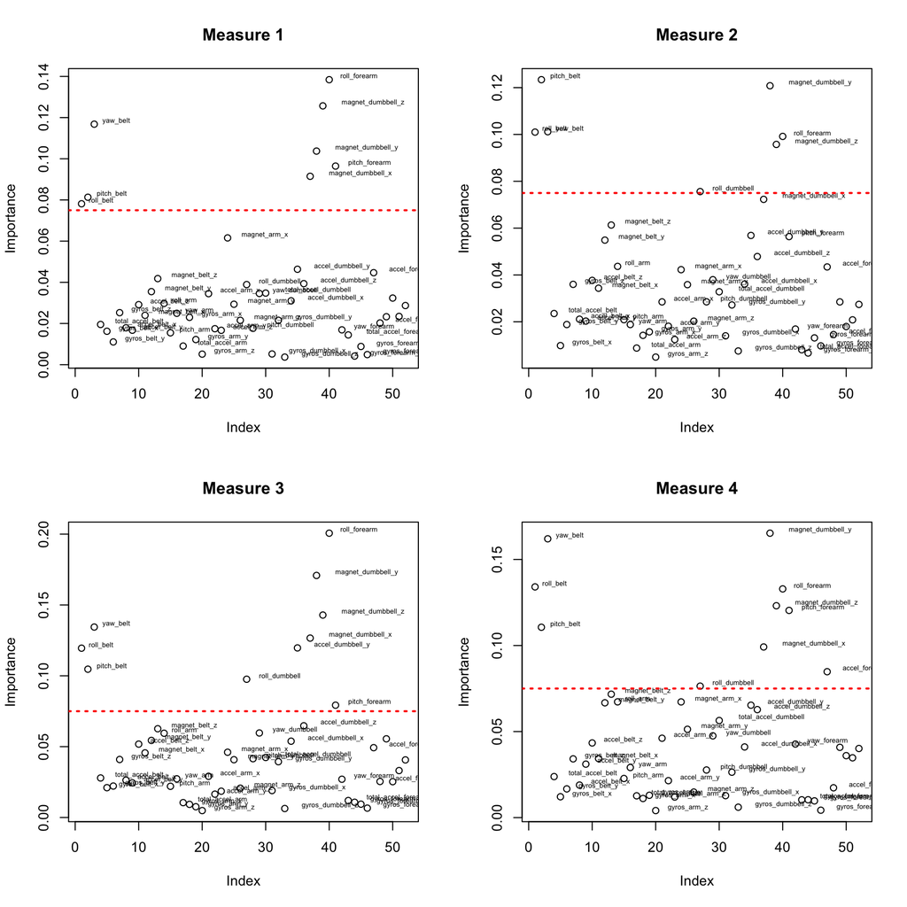

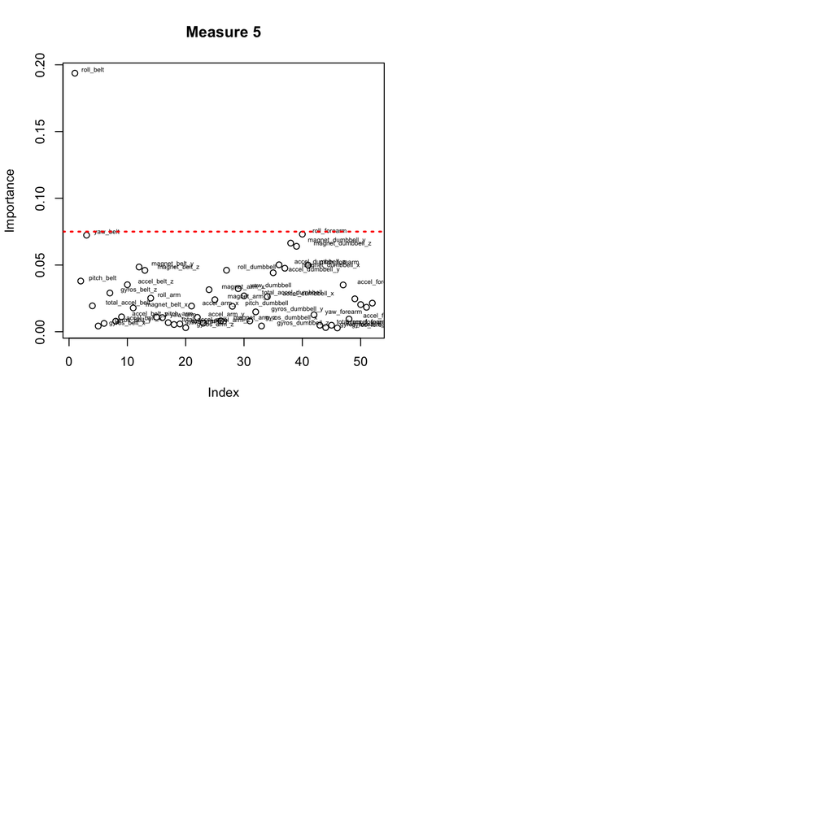

```r
library(calibrate)
par(mfrow = c(2, 2))
predictors <- c()
predplot <- c()

for (i in 1:5){
    x <- c(1:48)
    y <- modelFit$importance[,i]
    predplot[i] <- plot(y, main = paste("Measure", i), ylab="Importance")
    textxy(x,y,names(y))
    abline(h=0.075,col="red",lty=3, lwd = 2)
    predictors <- c(predictors, names(y[y>.075]))
}
```

We show a list showing the results of the three methods:

```r
#### Keep only unique values
library(BioPhysConnectoR)
modimpacc <- importance(modelFit, type=1)
modimpgini <- importance(modelFit, type=2)
predictorlist1 <- predictors <- sort(unique(predictors))
predictorlist2 <- sort(names(mat.sort(modimpacc,1,decreasing = TRUE)[1:11]))
predictorlist3 <- sort(names(mat.sort(modimpgini,1,decreasing = TRUE)[1:11]))
predictorlist <- cbind(predictorlist1,predictorlist2,predictorlist3)
colnames(predictorlist) <- c("Combined accuracy","Mean accuracy","Mean gini")

##### List predictors
library(xtable)
print(xtable(predictorlist, caption = "List of significant predictors"), type="html", comment=F)
```

List of significant predictors

|  | Combined accuracy | Mean accuracy | Mean gini |
| --- | --- | --- | --- |
| 1 | accel_dumbbell_y | accel_dumbbell_y | accel_dumbbell_y |
| 2 | accel_forearm_x | accel_dumbbell_z | magnet_belt_y |
| 3 | magnet_dumbbell_x | gyros_arm_y | magnet_dumbbell_x |
| 4 | magnet_dumbbell_y | gyros_dumbbell_z | magnet_dumbbell_y |
| 5 | magnet_dumbbell_z | magnet_dumbbell_y | magnet_dumbbell_z |
| 6 | pitch_belt | magnet_dumbbell_z | pitch_belt |
| 7 | pitch_forearm | magnet_forearm_z | pitch_forearm |
| 8 | roll_belt | pitch_belt | roll_belt |
| 9 | roll_dumbbell | pitch_forearm | roll_dumbbell |
| 10 | roll_forearm | roll_belt | roll_forearm |
| 11 | yaw_belt | yaw_belt | yaw_belt |

We show now a feature plot from the first 5 selected predictors:

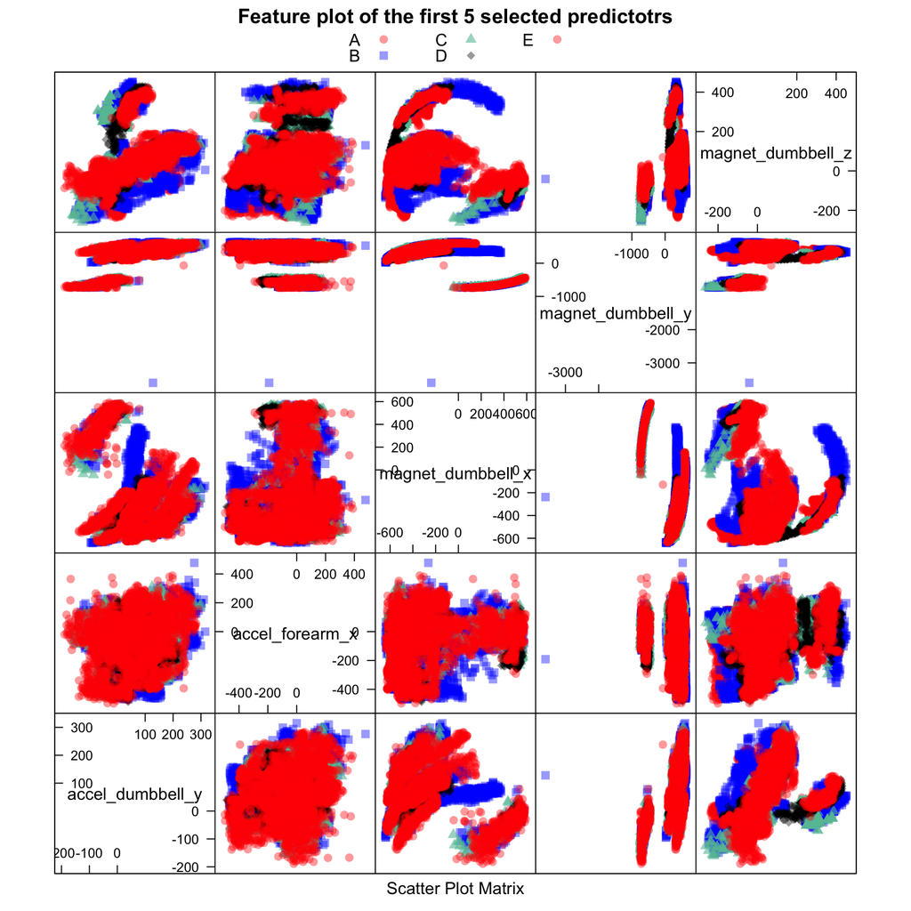

```r
library(AppliedPredictiveModeling)
transparentTheme(trans = .4)

library(caret)
featurePlot(x = training[,predictors][, 1:5],
            y = training$classe,
            plot = "pairs",
            main="Feature plot of the first 5 selected predictotrs",
            ## Add a key at the top
            auto.key = list(columns = 3))
```

We opt to take the result indicated in the column “Combined Accuracy” for the model selection process.

### Model Selection and Prediction

After having selected the most important predictors, we now select the best model for our prediction.

##### Fitting the model with decision tree

We first apply a tree model to best fit the training data.

```r
library(rpart)
set.seed(10302001)
treeModelFit <- rpart(classe ~ accel_dumbbell_y + accel_forearm_x +
                       magnet_dumbbell_x + magnet_dumbbell_y +
                       magnet_dumbbell_z + pitch_belt  + pitch_forearm + roll_belt +
                       roll_dumbbell + roll_forearm + yaw_belt,
                   method="class", data=trainingSet)
```

##### Fitting a model with random forest

Secondly, we fit the data with the train() method using k-fold corss validation. Since the processing performance of the train method is decreasing significantly with the large data sets, we reduce the trainig set accordingly and then apply the model fit.

###### Model with train() function

```r
InTrain<-createDataPartition(y=trainingSet$classe,p=0.5,list=FALSE)
trainingSet1<-trainingSet[InTrain,]

randomtreeModelFit1<-train(classe ~ accel_dumbbell_y + accel_forearm_x +
                              magnet_dumbbell_x + magnet_dumbbell_y +
                              magnet_dumbbell_z + pitch_belt  + pitch_forearm + roll_belt +
                              roll_dumbbell + roll_forearm + yaw_belt,
                data=trainingSet1,method="rf",
                trControl=trainControl(method="cv",number=5),
                prox=TRUE,allowParallel=TRUE)
```

###### Model with randomForest() function

Lastly, we apply a model fit with the randomForest() method.

```r
set.seed(10302001)
randomtreeModelFit2 <-randomForest(classe ~ accel_dumbbell_y + accel_forearm_x +
                                      magnet_dumbbell_x + magnet_dumbbell_y +
                                      magnet_dumbbell_z + pitch_belt  + pitch_forearm + roll_belt +
                                      roll_dumbbell + roll_forearm + yaw_belt,
                                  data = trainingSet, importance = TRUE)
```

##### Out-of-sample error

In this section we calculate the out-of-sample errors of the three models in question. We will compare the results of the three models, create a plot of the confusion matrices, and will select the best model for the final prediction.

###### First model

```r
treePredValues <- predict(treeModelFit, testingSet)
treePrediction <- c()
for (k in 1:nrow(testingSet)) {
    treePrediction <- c(treePrediction, names(which.max(treePredValues[k,])))
}
testingSet$Pred1 <-treePrediction == testingSet$classe
tablemod1<-table(treePrediction, testingSet$classe)
accuracymod1 <- sum(testingSet$Pred1)/nrow(testingSet)
outofsampleErrorMod1=1-accuracymod1
```

###### Second model

```r
predictionmod2 <- predict(randomtreeModelFit1, testingSet)
testingSet$Pred2 <- predictionmod2 == testingSet$classe
tablemod2<-table(predictionmod2, testingSet$classe)
accuracymod2 <- sum(testingSet$Pred2)/nrow(testingSet)
outofsampleErrorMod2=1-accuracymod2
```

###### Third model

```r
predictionmod3 <- predict(randomtreeModelFit2, testingSet)
testingSet$Pred3 <- predictionmod3 == testingSet$classe
tablemod3<-table(predictionmod3, testingSet$classe)
accuracymod3 <- sum(testingSet$Pred3)/nrow(testingSet)
outofsampleErrorMod3=1-accuracymod3

accerrlist <- rbind(cbind(round(accuracymod1,4),round(outofsampleErrorMod1,4))
    ,cbind(round(accuracymod2,4),round(outofsampleErrorMod2,4))
    ,cbind(round(accuracymod3,4),round(outofsampleErrorMod3,4)))

colnames(accerrlist) <- c("Model accuracy","Out-of-sample error")
library(xtable)
print(xtable(accerrlist, digits=c(4,4,4), caption = "List of model accuray and out-of-sample error"), type="html", comment=F)
```

List of model accuray and out-of-sample error

|  | Model accuracy | Out-of-sample error |
| --- | --- | --- |
| 1 | 0.7049 | 0.2951 |
| 2 | 0.9776 | 0.0224 |
| 3 | 0.9906 | 0.0094 |

We now calculate the confusion matrix for the three models.

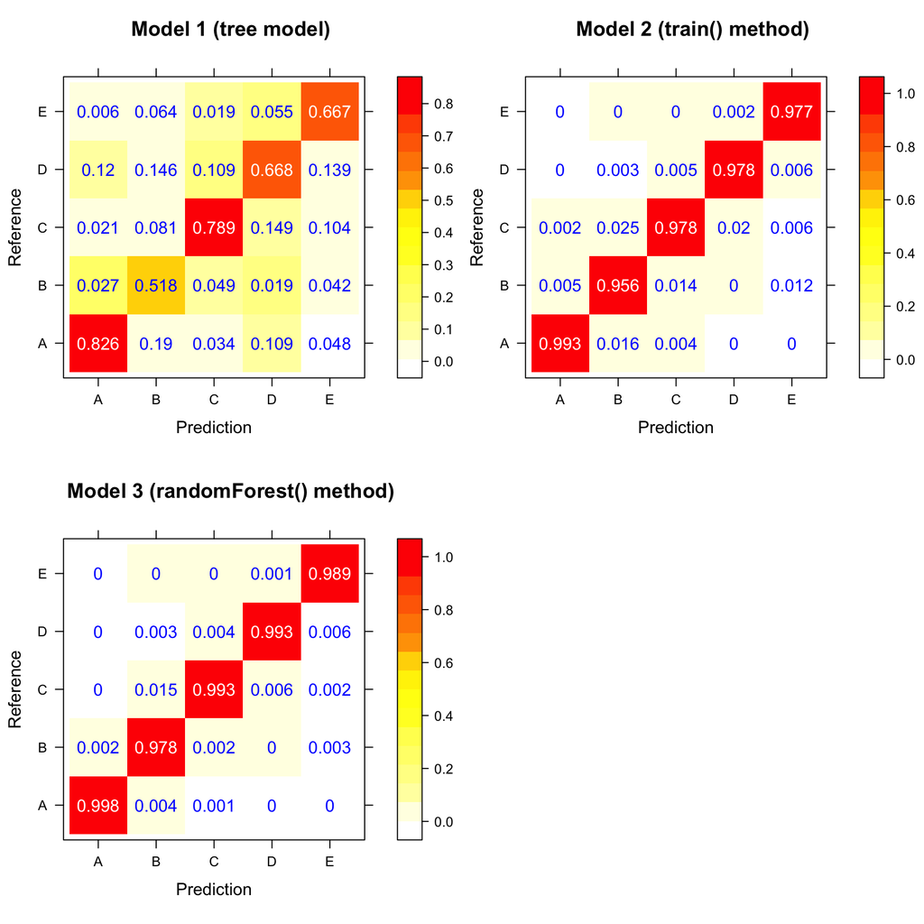

```r
library(calibrate)

#### Get confusion matrix
colpal <- colorRampPalette(c("white","yellow","red"))

### Model1
confmatrixmod1 <- as.matrix(confusionMatrix(treePrediction,testingSet$classe))
confmatrixmod1 <- round(apply(confmatrixmod1, 2, function(x) x / sum(x)), 3)
### Model2
confmatrixmod2 <- as.matrix(confusionMatrix(predictionmod2,testingSet$classe))
confmatrixmod2 <- round(apply(confmatrixmod2, 2, function(x) x / sum(x)), 3)
### Model3
confmatrixmod3 <- as.matrix(confusionMatrix(predictionmod3,testingSet$classe))
confmatrixmod3 <- round(apply(confmatrixmod3, 2, function(x) x / sum(x)), 3)

### Model1
cmPlot1 <- levelplot(confmatrixmod1, col.regions = colpal(20),
          xlab = 'Prediction', ylab = 'Reference', main="Model 1 (tree model)",
          panel = function(...) {
              panel.levelplot(...)
              panel.text(x = rep(1:5, each = 5), y = rep(1:5, 5),
                         labels = as.character(confmatrixmod1),
                         col = ifelse(confmatrixmod1 > .6, 'white', 'blue'))
          })


### Model2
cmPlot2 <- levelplot(confmatrixmod2, col.regions = colpal(20),
          xlab = 'Prediction', ylab = 'Reference', main="Model 2 (train() method)",
          panel = function(...) {
              panel.levelplot(...)
              panel.text(x = rep(1:5, each = 5), y = rep(1:5, 5),
                         labels = as.character(confmatrixmod2),
                         col = ifelse(confmatrixmod2 > .6, 'white', 'blue'))
          })

### Model3
cmPlot3 <- levelplot(confmatrixmod3, col.regions = colpal(20),
          xlab = 'Prediction', ylab = 'Reference', main="Model 3 (randomForest() method)",
          panel = function(...) {
              panel.levelplot(...)
              panel.text(x = rep(1:5, each = 5), y = rep(1:5, 5),
                         labels = as.character(confmatrixmod3),
                         col = ifelse(confmatrixmod3 > .6, 'white', 'blue'))
          })

library(gridExtra)
grid.arrange(cmPlot1, cmPlot2,cmPlot3, ncol=2)
```

Based on the accuracy and confusion matrix results, we see that the tree model is preforming the least with an accuracy of 0.7049. The k-fold cross-validation model fit with the rain() method performs better with an accuracy of 0.9776. The best fit, however, gives the fit with the randomForest() method with an accuracy of 0.9906. Therefore, we select the third model using the randomForest() method as our best model to predict the ‘classe’ outcome for the test data set.

### Predicting the outcome

The predction of our best model is as follows:

```r
#### Best model fit prediction
finalPrediction <- predict(randomtreeModelFit2, testing)

library(xtable)
print(xtable(data.frame(finalPrediction), caption = "Prediction of classe outcome for the test set"), type="html", comment=F)
```

Prediction of classe outcome for the test set

|  | finalPrediction |
| --- | --- |
| 1 | B |
| 2 | A |
| 3 | B |
| 4 | A |
| 5 | A |
| 6 | E |
| 7 | D |
| 8 | B |
| 9 | A |
| 10 | A |
| 11 | B |
| 12 | C |
| 13 | B |
| 14 | A |
| 15 | E |
| 16 | E |
| 17 | A |
| 18 | B |
| 19 | B |
| 20 | B |

##### Export results for validation

```r
answers <- finalPrediction
pml_write_files = function(x){
    n = length(x)
    for(i in 1:n){
        filename = paste0("problem_id_",i,".txt")
        write.table(x[i],file=filename,quote=FALSE,row.names=FALSE,col.names=FALSE)
    }
}

pml_write_files(answers)
```

### References

1. Ugulino, W.; Cardador, D.; Vega, K.; Velloso, E.; Milidiu, R.; Fuks, H. Wearable Computing: Accelerometers’ Data Classification of Body Postures and Movements. Proceedings of 21st Brazilian Symposium on Artificial Intelligence. Advances in Artificial Intelligence - SBIA 2012. In: Lecture Notes in Computer Science. , pp. 52-61. Curitiba, PR: Springer Berlin / Heidelberg, 2012. ISBN 978-3-642-34458-9. DOI: 10.1007/978-3-642-34459-6_6.
2. http://www.bios.unc.edu/~dzeng/BIOS740/randomforest.pdf
3. http://stats.stackexchange.com/questions/61090/how-to-split-a-data-set-to-do-10-fold-cross-validation
4. http://bigcomputing.blogspot.de/2014/10/an-example-of-using-random-forest-in.html
5. http://www.listendata.com/2015/03/caret-package-implementation-in-r.html
6. http://topepo.github.io/caret/varimp.html
7. http://en.wikipedia.org/wiki/Wearable_technology